# Burghart Dissertation: Aim 1 code

Mark Burghart

November 12, 2017

## **Aim 1.a:**

## Assess Injury date vs Evaluation date

Assumptions can be made that an individual will reach out to a healthcare provider soon after a concussion, but this assumption hasn’t been thoroughly tested or reported. With this aim, I manually reviewed all the text-based evaluation notes from the Concussion Clinic at KUMC. After review, I was able to find and document 136 individual injury dates and assess the difference between this date and the date of evaluation for a concussion.

```r
#create dataframe with 1 row per person with min/max dates
aim1_df <- sqldf("select distinct patient_num
                 ,MIN(note_date) as first_visit_date__Date
                 ,MIN(injury_date) as injury_date__Date
                  ,MAX(last_visit_date) as last_visit_date__Date
                 from data
                 group by patient_num", method = "name__class")
```

The resulting dataset looks like:

```r
head(aim1_df)
```

```
##   patient_num first_visit_date injury_date last_visit_date
## 1        1060       2013-10-11  2013-06-01      2013-11-05
## 2        2589       2014-09-29  2014-09-22      2014-09-29
## 3        8456       2015-10-20  2015-09-27      2015-10-20
## 4        9625       2014-02-09  2014-02-02      2014-02-09
## 5       21056       2013-02-14  2013-02-10      2013-03-11
## 6       31976       2013-01-30  2013-01-10      2013-12-24
```

At this point, I need to generate a new variable *‘wait_days’*, which represents the amount of time between a person’s documented injury date and their date of evaluation at the concussion clinic.

```r
aim1_df$wait_days <- as.numeric(aim1_df$first_visit_date - aim1_df$injury_date)
#Descriptive statistics:
summary(aim1_df)
```

```
##   patient_num      first_visit_date      injury_date
##  Min.   :   1060   Min.   :2012-10-11   Min.   :2012-09-24
##  1st Qu.: 535365   1st Qu.:2014-02-06   1st Qu.:2014-01-31
##  Median :1018057   Median :2014-10-14   Median :2014-10-02
##  Mean   :1072376   Mean   :2014-09-16   Mean   :2014-08-30
##  3rd Qu.:1528580   3rd Qu.:2015-03-24   3rd Qu.:2015-03-16
##  Max.   :2174121   Max.   :2015-10-20   Max.   :2015-09-27
##  last_visit_date        wait_days
##  Min.   :2012-10-11   Min.   :  0.00
##  1st Qu.:2014-04-20   1st Qu.:  2.00
##  Median :2014-10-29   Median :  6.00
##  Mean   :2014-10-10   Mean   : 17.05
##  3rd Qu.:2015-04-30   3rd Qu.: 20.00
##  Max.   :2015-10-20   Max.   :132.00
```

The distribution of wait times appears to be heavily skewed to lesser days of wait, although some longer waits were noted.

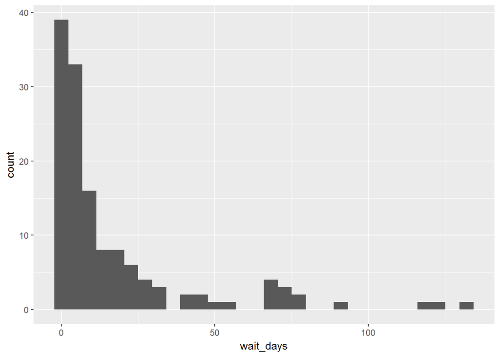

## Discussion

For aim 1.a, I wanted to look at the difference in injury date vs. evaluation date for each person. *On average, nearly 17 days* passed between injury date and evaluation date. This data was skewed to outliers on the high end, as the *median was 6 days wait*. Range = 0 days to 132 days. That being said, I think it would be **the best choice to use the date of evaluation, as opposed to injury date for the work moving forward**, as this event is clearly documented and referenced. I was able to verify the injury date in roughly 1/3rd of the encounters at the concussion clinic.

## **Aim 1.b:**

# Does last visit indicate discharge from clinic?

The was little stastical analysis for this aim, as this entailed manual note review. Generally speaking, there were few formal discharges. From the reviewed notes, the common discharge procedure was *‘patient will follow up if there are any concerns’* which makes sense clinically, but from a data perspective, I can’t verify a discretely recorded event for when the person returns to their previous level of functioning. The assumption that an individual will discontinue services when no longer symptomatic will remain, as I cannot verify this event.

Moving forward, *Length of Treatment (LOT)* should and will replace my original plan of trying to determine a person’s length of *recovery* by stating that a person will be seen close to their injury date, and will be discharged from services when they have returned back to normal. I can determine the length of treatment time from my data, and I will plan on analyzing this as my main outcome of interest.

# Distribution of length of treatment (n = 136):

```
##    Min. 1st Qu.  Median    Mean 3rd Qu.    Max.
##    0.00    0.00    8.00   23.81   24.25  377.00
```

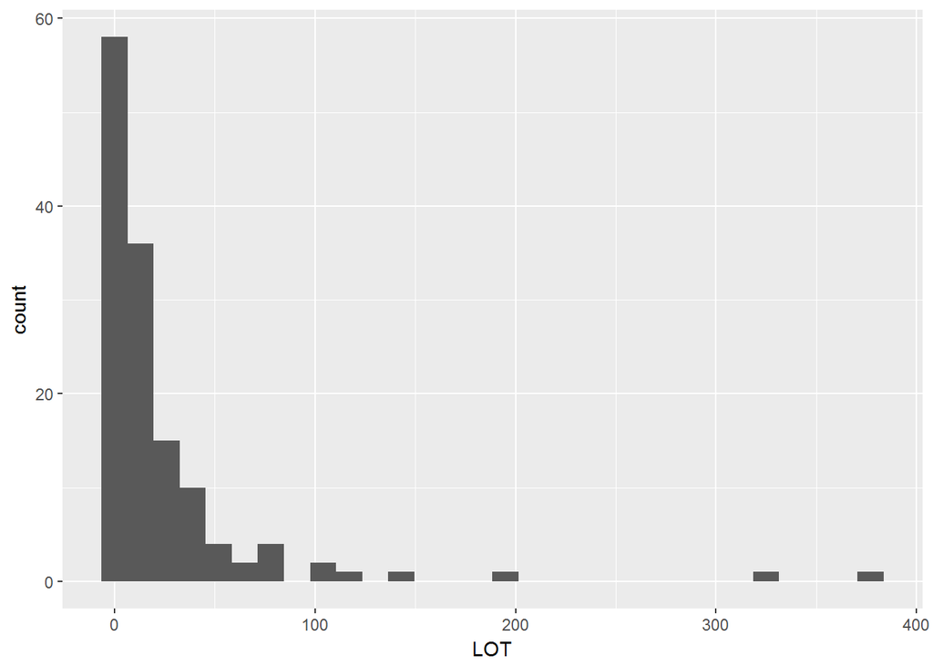

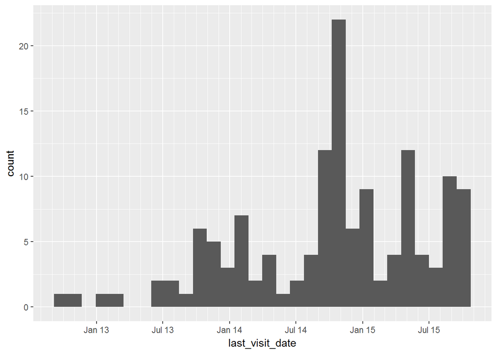